# DevPavBias_Analyses

Hillary Raab

July 12, 2019

# Descriptive Statistics

Mean age for each age group (Children 8-12 years old; Adolescents 13-17 years old; Adults 18-25 years old)

- **Children**:

  Table continues below

  |  | vars | n | mean | sd | median | trimmed | mad | min |
  | --- | --- | --- | --- | --- | --- | --- | --- | --- |
  | **Age.Group*** | 1 | 20 | 1 | 0 | 1 | 1 | 0 | 1 |
  | **age** | 2 | 20 | 10.55 | 1.337 | 10.61 | 10.62 | 1.754 | 8.238 |

  |  | max | range | skew | kurtosis | se |
  | --- | --- | --- | --- | --- | --- |
  | **Age.Group*** | 1 | 0 | NA | NA | 0 |
  | **age** | 12.68 | 4.438 | -0.2463 | -1.298 | 0.2989 |

- **Adolescents**:

  Table continues below

  |  | vars | n | mean | sd | median | trimmed | mad | min |
  | --- | --- | --- | --- | --- | --- | --- | --- | --- |
  | **Age.Group*** | 1 | 20 | 2 | 0 | 2 | 2 | 0 | 2 |
  | **age** | 2 | 20 | 15.38 | 1.449 | 15.5 | 15.4 | 1.463 | 13.05 |

  |  | max | range | skew | kurtosis | se |
  | --- | --- | --- | --- | --- | --- |
  | **Age.Group*** | 2 | 0 | NA | NA | 0 |
  | **age** | 17.48 | 4.433 | -0.07132 | -1.386 | 0.3241 |

- **Adults**:

  Table continues below

  |  | vars | n | mean | sd | median | trimmed | mad | min |
  | --- | --- | --- | --- | --- | --- | --- | --- | --- |
  | **Age.Group*** | 1 | 21 | 3 | 0 | 3 | 3 | 0 | 3 |
  | **age** | 2 | 21 | 21.28 | 2.192 | 21.13 | 21.17 | 2.886 | 18.2 |

  |  | max | range | skew | kurtosis | se |
  | --- | --- | --- | --- | --- | --- |
  | **Age.Group*** | 3 | 0 | NA | NA | 0 |
  | **age** | 25.78 | 7.581 | 0.2663 | -1.07 | 0.4783 |

Number of males and females in each age group

| Age.Group | M.or.F | n |
| --- | --- | --- |
| Children | F | 10 |
| Children | M | 10 |
| Adolescents | F | 11 |
| Adolescents | M | 9 |
| Adults | F | 10 |
| Adults | M | 11 |

# Figure 2a - Tickets Won

Total number of tickets won throughout the task plotted as a function of age

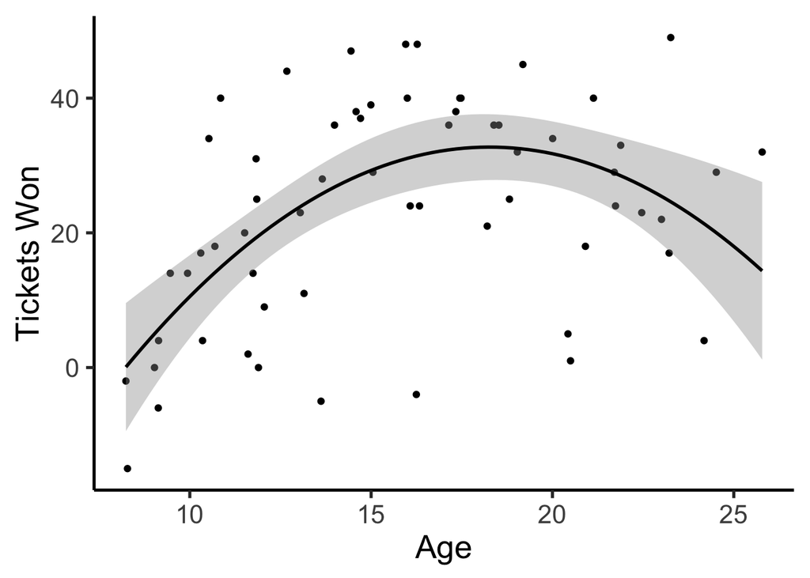

Model comparison for age and age-squared as predictors of total tickets.

```
## Analysis of Variance Table
##
## Model 1: totalTickets ~ z_age
## Model 2: totalTickets ~ z_age + z_ageSq
##   Res.Df   RSS Df Sum of Sq      F    Pr(>F)
## 1     59 13639
## 2     58 10696  1    2943.1 15.959 0.0001848 ***
## ---
## Signif. codes:  0 '***' 0.001 '**' 0.01 '*' 0.05 '.' 0.1 ' ' 1
```

Fitting linear model: totalTickets ~ z_age + z_ageSq

|  | Estimate | Std. Error | t value | Pr(>\|t\|) |
| --- | --- | --- | --- | --- |
| **(Intercept)** | 30.8 | 2.507 | 12.29 | 8.731e-18 |
| **z_age** | 7.523 | 1.804 | 4.17 | 0.0001031 |
| **z_ageSq** | -7.334 | 1.836 | -3.995 | 0.0001848 |

## Cohen’s f^2 for tickets won

Cohen’s f^2 local effect size for age on tickets won given age-squared: 0.2997493

Cohen’s f^2 local effect size for age-squared on tickets won given age: 0.2751554

# Figure 2b - Mean Accuracy

# Mean Accuracy by Age Group

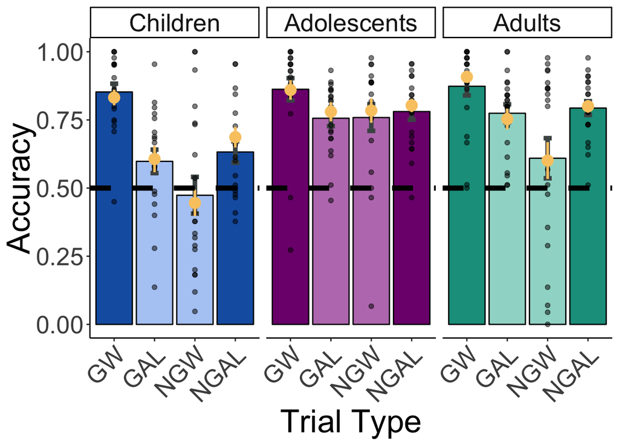

# Age predicts each trial type

```
## Analysis of Variance Table
##
## Model 1: meanAcc ~ z_age
## Model 2: meanAcc ~ (z_age + z_ageSq)
##   Res.Df    RSS Df Sum of Sq      F Pr(>F)
## 1     59 1.4561
## 2     58 1.4422  1  0.013854 0.5571 0.4584
```

```
## Analysis of Variance Table
##
## Model 1: meanAcc ~ z_age
## Model 2: meanAcc ~ (z_age + z_ageSq)
##   Res.Df    RSS Df Sum of Sq      F   Pr(>F)
## 1     59 1.5368
## 2     58 1.3120  1   0.22479 9.9372 0.002564 **
## ---
## Signif. codes:  0 '***' 0.001 '**' 0.01 '*' 0.05 '.' 0.1 ' ' 1
```

```
## Analysis of Variance Table
##
## Model 1: meanAcc ~ z_age
## Model 2: meanAcc ~ (z_age + z_ageSq)
##   Res.Df    RSS Df Sum of Sq      F   Pr(>F)
## 1     59 5.5268
## 2     58 4.7967  1    0.7301 8.8282 0.004311 **
## ---
## Signif. codes:  0 '***' 0.001 '**' 0.01 '*' 0.05 '.' 0.1 ' ' 1
```

```
## Analysis of Variance Table
##
## Model 1: meanAcc ~ z_age
## Model 2: meanAcc ~ (z_age + z_ageSq)
##   Res.Df    RSS Df Sum of Sq      F   Pr(>F)
## 1     59 1.2575
## 2     58 1.0725  1   0.18499 10.004 0.002486 **
## ---
## Signif. codes:  0 '***' 0.001 '**' 0.01 '*' 0.05 '.' 0.1 ' ' 1
```

Fitting linear model: meanAcc ~ z_age

|  | Estimate | Std. Error | t value | Pr(>\|t\|) |
| --- | --- | --- | --- | --- |
| **(Intercept)** | 0.8631 | 0.02011 | 42.91 | 3.449e-46 |
| **z_age** | 0.01313 | 0.02028 | 0.6472 | 0.52 |

Fitting linear model: meanAcc ~ (z_age + z_ageSq)

|  | Estimate | Std. Error | t value | Pr(>\|t\|) |
| --- | --- | --- | --- | --- |
| **(Intercept)** | 0.7737 | 0.02776 | 27.87 | 2.812e-35 |
| **z_age** | 0.08886 | 0.01998 | 4.447 | 3.991e-05 |
| **z_ageSq** | -0.06409 | 0.02033 | -3.152 | 0.002564 |

Fitting linear model: meanAcc ~ (z_age + z_ageSq)

|  | Estimate | Std. Error | t value | Pr(>\|t\|) |
| --- | --- | --- | --- | --- |
| **(Intercept)** | 0.7275 | 0.05308 | 13.71 | 7.673e-20 |
| **z_age** | 0.0842 | 0.03821 | 2.204 | 0.03151 |
| **z_ageSq** | -0.1155 | 0.03887 | -2.971 | 0.004311 |

Fitting linear model: meanAcc ~ (z_age + z_ageSq)

|  | Estimate | Std. Error | t value | Pr(>\|t\|) |
| --- | --- | --- | --- | --- |
| **(Intercept)** | 0.7937 | 0.0251 | 31.62 | 2.892e-38 |
| **z_age** | 0.07952 | 0.01807 | 4.402 | 4.672e-05 |
| **z_ageSq** | -0.05814 | 0.01838 | -3.163 | 0.002486 |

## F^2 for each trial type

Cohen’s f^2 local effect size for age on GW accuracy: 0.0070988

Cohen’s f^2 local effect size for age on GAL accuracy given age-squared: 0.3409992

Cohen’s f^2 local effect size for age-squared on GAL accuracy given age: 0.171331

Cohen’s f^2 local effect size for age on NGW accuracy given age-squared: 0.0837494

Cohen’s f^2 local effect size for age-squared on NGW accuracy given age: 0.1522098

Cohen’s f^2 local effect size for age on NGAL accuracy given age-squared: 0.334054

Cohen’s f^2 local effect size for age-squared on NGAL accuracy given age: 0.1724839

# Supplementary Figure 1 - Learning Curves by Age Group

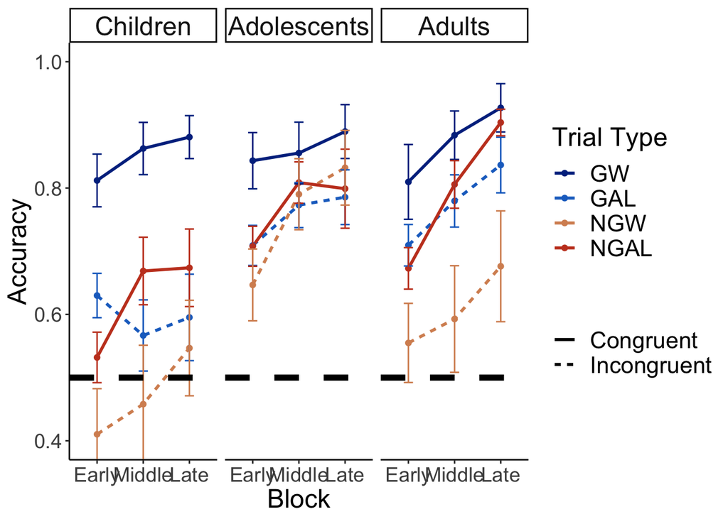

# Figure 3 - Pavlovian Performance Bias Score

Calculate PIT bias as the [average of Go on GW + NGW divided by total go] PLUS [NoGo on GAL + NGAL divided by total NoGo]

```
## Analysis of Variance Table
##
## Model 1: PavPerBias ~ z_age
## Model 2: PavPerBias ~ z_age + z_ageSq
##   Res.Df     RSS Df Sum of Sq      F  Pr(>F)
## 1     59 0.73233
## 2     58 0.68358  1   0.04875 4.1363 0.04656 *
## ---
## Signif. codes:  0 '***' 0.001 '**' 0.01 '*' 0.05 '.' 0.1 ' ' 1
```

Fitting linear model: PavPerBias ~ z_age + z_ageSq

|  | Estimate | Std. Error | t value | Pr(>\|t\|) |
| --- | --- | --- | --- | --- |
| **(Intercept)** | 0.5467 | 0.02004 | 27.28 | 8.831e-35 |
| **z_age** | -0.01833 | 0.01442 | -1.271 | 0.2089 |
| **z_ageSq** | 0.02985 | 0.01468 | 2.034 | 0.04656 |

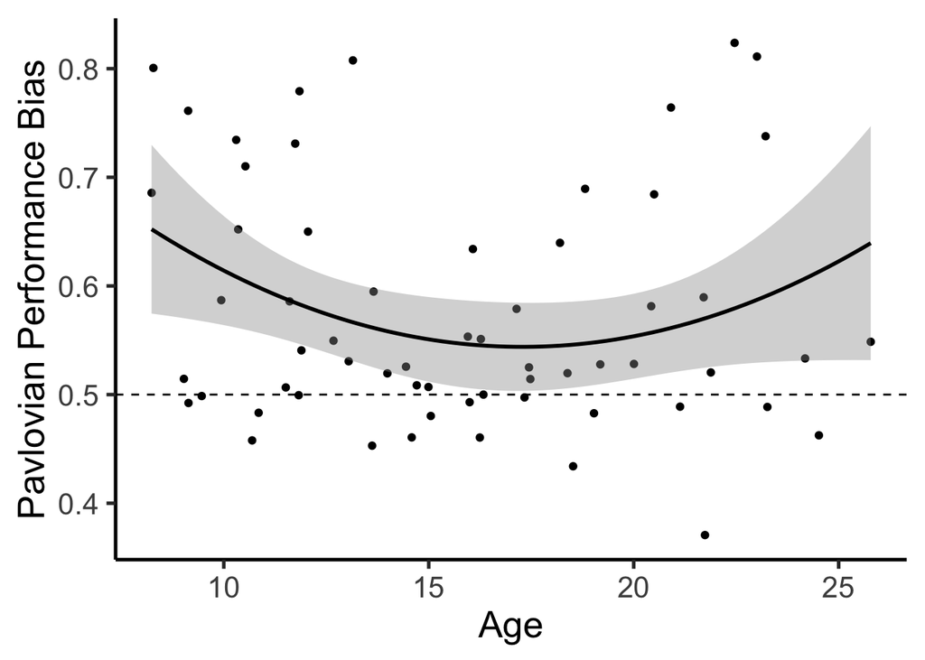

## Cohen’s f^2 for Pavlovian Performance Bias

Cohen’s f^2 local effect size for age on Pav Performance Bias given age-squared: 0.0278366

Cohen’s f^2 local effect size for age-squared on Pav Performance Bias given age: 0.0713159

# Supplementary figure 2 - Relationship between Punishment Suppression and Reward Invigoration Pav Performance bias

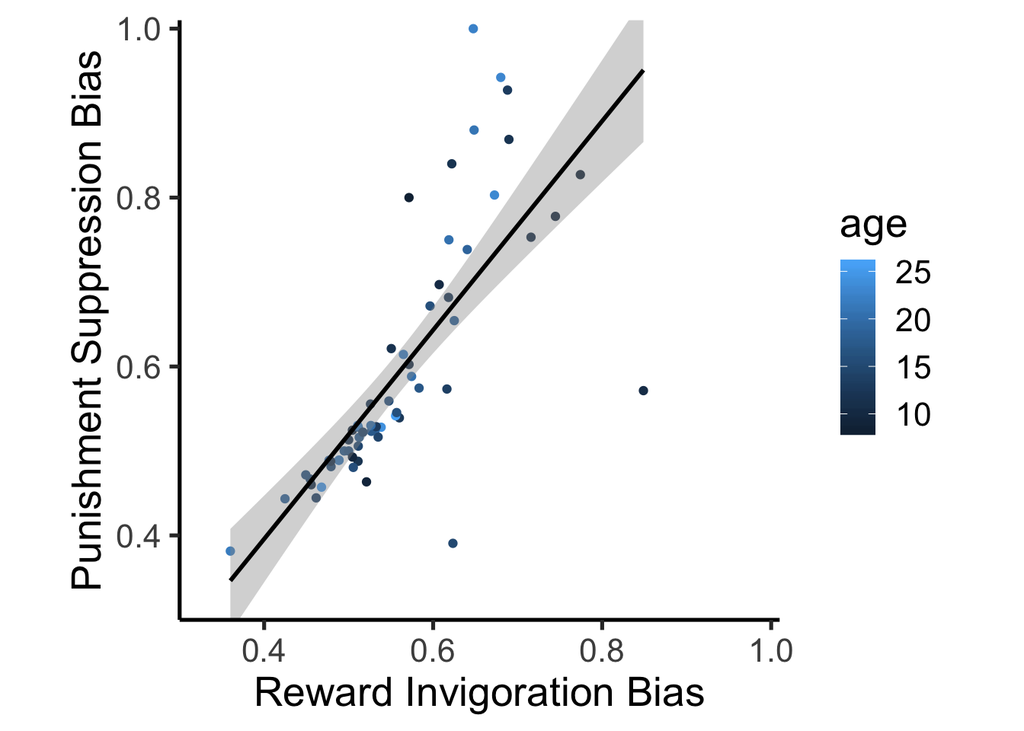

```
##
##  Pearson's product-moment correlation
##
## data:  PavBias$RewInv and PavBias$PunSupp
## t = 8.7941, df = 59, p-value = 2.522e-12
## alternative hypothesis: true correlation is not equal to 0
## 95 percent confidence interval:
##  0.6186732 0.8447595
## sample estimates:
##       cor
## 0.7531562
```

```
##   estimate     p.value statistic  n gp  Method
## 1  0.76277 1.41414e-12  8.983074 61  1 pearson
```

# Supplementary Table 1 - Valence X Action Logistic Regression Analysis

## Correct choice mixed effects model with subject specific intercepts but not slopes

```
## Fitting 4 (g)lmer() models.
```

```
## Fitting 8 (g)lmer() models.
```

```
## Fitting 12 (g)lmer() models.
```

```
## Data: data
## Models:
## pitMixedVxA.m: corrResp ~ valence * action + (1 | subjID)
## pitMixedVxAxAge.m: corrResp ~ valence * action * z_age + (1 | subjID)
##                   Df   AIC   BIC  logLik deviance  Chisq Chi Df Pr(>Chisq)
## pitMixedVxA.m      5 10900 10936 -5444.8    10890
## pitMixedVxAxAge.m  9 10886 10952 -5434.1    10868 21.577      4  0.0002433
##
## pitMixedVxA.m
## pitMixedVxAxAge.m ***
## ---
## Signif. codes:  0 '***' 0.001 '**' 0.01 '*' 0.05 '.' 0.1 ' ' 1
```

```
## Data: data
## Models:
## pitMixedVxAxAge.m: corrResp ~ valence * action * z_age + (1 | subjID)
## pitMixedVxAxAgeAgeSq.m: corrResp ~ valence * action * (z_age + z_ageSq) + (1 | subjID)
##                        Df   AIC   BIC  logLik deviance  Chisq Chi Df
## pitMixedVxAxAge.m       9 10886 10952 -5434.1    10868
## pitMixedVxAxAgeAgeSq.m 13 10855 10949 -5414.3    10829 39.464      4
##                        Pr(>Chisq)
## pitMixedVxAxAge.m
## pitMixedVxAxAgeAgeSq.m  5.587e-08 ***
## ---
## Signif. codes:  0 '***' 0.001 '**' 0.01 '*' 0.05 '.' 0.1 ' ' 1
```

```
## Generalized linear mixed model fit by maximum likelihood (Laplace
##   Approximation) [glmerMod]
##  Family: binomial  ( logit )
## Formula: corrResp ~ valence * action * (z_age + z_ageSq) + (1 | subjID)
##    Data: data
## Control:
## glmerControl(optimizer = "bobyqa", optCtrl = list(maxfun = 1e+05))
##
##      AIC      BIC   logLik deviance df.resid
##  10854.6  10949.2  -5414.3  10828.6    10610
##
## Scaled residuals:
##     Min      1Q  Median      3Q     Max
## -6.8353 -0.7145  0.3812  0.5801  2.0786
##
## Random effects:
##  Groups Name        Variance Std.Dev.
##  subjID (Intercept) 0.5117   0.7153
## Number of obs: 10623, groups:  subjID, 61
##
## Fixed effects:
##                          Estimate Std. Error z value Pr(>|z|)
## (Intercept)               1.53442    0.13782  11.133  < 2e-16 ***
## valence1                 -0.09609    0.03701  -2.596 0.009422 **
## action1                  -0.24059    0.03706  -6.492 8.47e-11 ***
## z_age                     0.35490    0.09840   3.607 0.000310 ***
## z_ageSq                  -0.32854    0.10046  -3.270 0.001074 **
## valence1:action1          0.30848    0.03711   8.313  < 2e-16 ***
## valence1:z_age            0.07768    0.02438   3.187 0.001438 **
## valence1:z_ageSq          0.01120    0.02600   0.431 0.666736
## action1:z_age             0.04838    0.02439   1.983 0.047318 *
## action1:z_ageSq          -0.09469    0.02608  -3.631 0.000282 ***
## valence1:action1:z_age   -0.06039    0.02443  -2.472 0.013422 *
## valence1:action1:z_ageSq  0.09855    0.02612   3.773 0.000161 ***
## ---
## Signif. codes:  0 '***' 0.001 '**' 0.01 '*' 0.05 '.' 0.1 ' ' 1
##
## Correlation of Fixed Effects:
##             (Intr) valnc1 actin1 z_age  z_agSq vln1:1 vln1:_ vl1:_S act1:_
## valence1    -0.023
## action1     -0.046  0.176
## z_age        0.171 -0.003 -0.005
## z_ageSq     -0.722  0.017  0.034 -0.230
## valnc1:ctn1  0.054 -0.153 -0.090  0.005 -0.039
## valenc1:z_g -0.003  0.184  0.016 -0.024  0.008 -0.015
## vlnc1:z_gSq  0.018 -0.748 -0.133  0.008 -0.024  0.118 -0.186
## action1:z_g -0.005  0.016  0.185 -0.039  0.000 -0.014  0.158  0.003
## actn1:z_gSq  0.035 -0.133 -0.748  0.000 -0.046  0.072  0.003  0.177 -0.184
## vlnc1:ct1:_  0.006 -0.015 -0.014  0.043  0.001  0.185 -0.143  0.004 -0.110
## vlnc1:c1:_S -0.040  0.117  0.072  0.001  0.051 -0.748  0.004 -0.158  0.034
##             ac1:_S vl1:1:_
## valence1
## action1
## z_age
## z_ageSq
## valnc1:ctn1
## valenc1:z_g
## vlnc1:z_gSq
## action1:z_g
## actn1:z_gSq
## vlnc1:ct1:_  0.034
## vlnc1:c1:_S -0.107 -0.185
```

# Computational Modeling Results

I compared a set of nested models that included 1 learning rate, 2 learning rates, squashed softmax, Go Bias, Pav Bias, Reward Sensitivity, and Punishment Sensitivity. The model that fit best according to median AIC was Go+Pav+RewSens using the squashed softmax choice fxn.

These data were fit using Matlab fmincon with the following bounds on the parameters: learning rate and squashed softmax: 0 to 1 Go Bias: -inf to inf Pav Bias, RewSens, PunSens: 0 to inf

The following priors were used: log(betapdf(alphaPos,1.1,1.1)); log(betapdf(alphaNeg,1.1,1.1)) log(betapdf(squashedSoftmax,1.1,1.1)); log(normpdf(gobias,0,1)); log(gampdf(pavbias,2,3)); log(gampdf(posRewardSens,2,3));

Here I examined linear and quadratic age-related changes in the parameter estimates. All regressions were run using z-scored age and age-squared. First I ran a regression testing the effect of age on the parameter and then a model testing age and age-squared. An anova was used to compare which model provided a better fit.

## Table 1 - Mean parameter estimates

Child Estimates mean; Quartile: 0% 25% 50% 75% 100%):  
Lapse rate (xi): 0.1614673 ; 0.0027404, 0.0156634, 0.0748296, 0.2502231, 0.9443768  
Learning rate (ep): 0.3043221 ; 0.0021255, 0.0549942, 0.2228013, 0.4666144, 0.8701484  
Go bias (b): 0.5250223 ; -1.8406279, 0.1432141, 0.5365918, 0.9416836, 1.866523  
Pav bias (pi): 2.331024 ; 0.1043104, 0.50211, 1.3876999, 2.6938712, 10.860074  
Reward sensitivity (rhoRew): 3.5035601 ; 0.3616235, 1.7500183, 3.1594521, 4.246677, 8.6107728

Adolescent Estimates mean(sem):  
Lapse rate (xi): 0.1504589 ; 0.0013349, 0.0078626, 0.0666118, 0.2288071, 0.9936414  
Learning rate (ep): 0.3594728 ; 5.7879610^{-4}, 0.1734913, 0.3639567, 0.5167056, 0.748636  
Go bias (b): 0.2072342 ; -0.6433589, -0.0072791, 0.2149482, 0.4912007, 0.9119195  
Pav bias (pi): 0.5706268 ; 0.0565799, 0.1665516, 0.229184, 0.4111567, 2.8603051  
Reward sensitivity (rhoRew): 5.8285008 ; 2.511779, 3.8346592, 4.8461287, 8.3833533, 10.6717154

Adult Estimates mean(sem):  
Lapse rate (xi): 0.0973023 ; 0.001415, 0.0066559, 0.0258965, 0.1392928, 0.6448503  
Learning rate (ep): 0.4222346 ; 0.0310284, 0.1637737, 0.4821147, 0.5730101, 0.9834867  
Go bias (b): 0.5426659 ; -1.1687055, 0.0059665, 0.3100345, 1.0404445, 3.6375982  
Pav bias (pi): 0.6724703 ; 0.0390492, 0.1127604, 0.3976082, 0.8622133, 3.4328018  
Reward sensitivity (rhoRew): 5.7890412 ; 0.7750687, 2.3294414, 4.5116188, 8.7583127, 14.6762036

# Supplementary figure 3 -Parameter Estimates by Age

No effect of age on alpha

No effect of age on the softmax

Sig. age-squared effect on Go bias

Sig. age and age-squared effect on Pav bias

Sig. age effect on Rew Sens

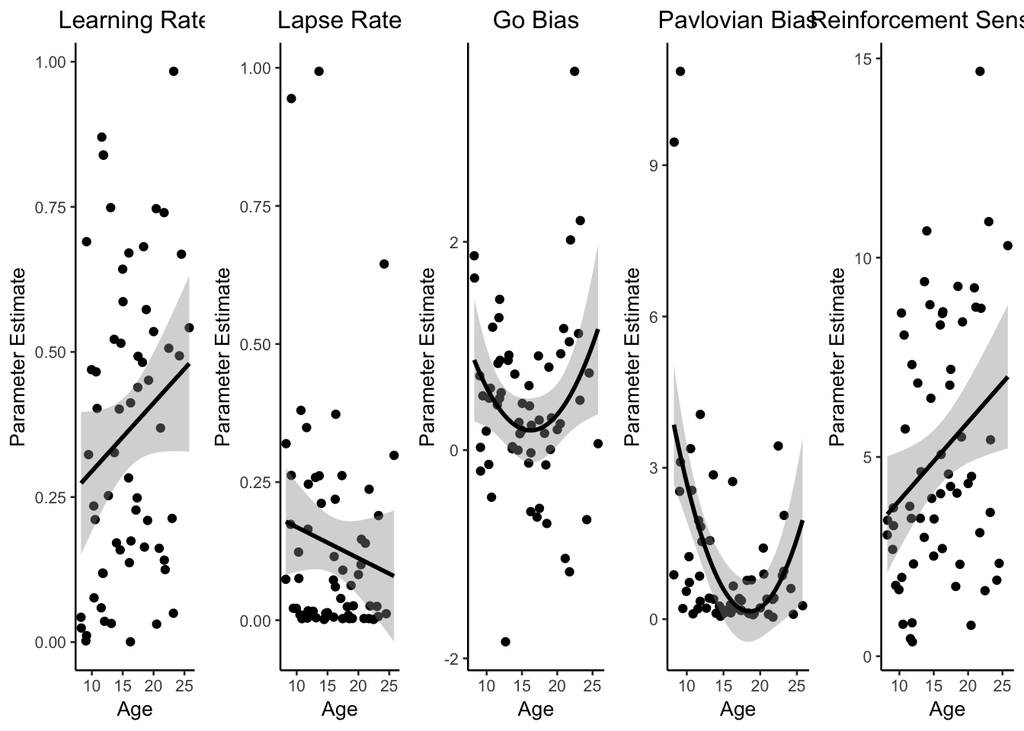

## Model Comparison ANOVA: Age vs. Age+Age^2

```
## Analysis of Variance Table
##
## Model 1: alpha ~ z_age
## Model 2: alpha ~ z_age + z_ageSq
##   Res.Df    RSS Df Sum of Sq      F Pr(>F)
## 1     59 3.9457
## 2     58 3.9375  1 0.0082103 0.1209 0.7293
```

```
## Analysis of Variance Table
##
## Model 1: squashedSoftmax ~ z_age
## Model 2: squashedSoftmax ~ z_age + z_ageSq
##   Res.Df    RSS Df Sum of Sq      F  Pr(>F)
## 1     59 2.4244
## 2     58 2.2979  1   0.12645 3.1916 0.07924 .
## ---
## Signif. codes:  0 '***' 0.001 '**' 0.01 '*' 0.05 '.' 0.1 ' ' 1
```

```
## Analysis of Variance Table
##
## Model 1: GoBias ~ z_age
## Model 2: GoBias ~ z_age + z_ageSq
##   Res.Df    RSS Df Sum of Sq      F  Pr(>F)
## 1     59 44.259
## 2     58 41.108  1    3.1519 4.4472 0.03929 *
## ---
## Signif. codes:  0 '***' 0.001 '**' 0.01 '*' 0.05 '.' 0.1 ' ' 1
```

```
## Analysis of Variance Table
##
## Model 1: PavBias ~ z_age
## Model 2: PavBias ~ z_age + z_ageSq
##   Res.Df    RSS Df Sum of Sq      F   Pr(>F)
## 1     59 197.25
## 2     58 163.63  1    33.617 11.916 0.001045 **
## ---
## Signif. codes:  0 '***' 0.001 '**' 0.01 '*' 0.05 '.' 0.1 ' ' 1
```

```
## Analysis of Variance Table
##
## Model 1: RewSens ~ z_age
## Model 2: RewSens ~ z_age + z_ageSq
##   Res.Df    RSS Df Sum of Sq      F Pr(>F)
## 1     59 554.68
## 2     58 544.75  1    9.9243 1.0566 0.3083
```

## Regression Results Age

Fitting linear model: alpha ~ z_age

|  | Estimate | Std. Error | t value | Pr(>\|t\|) |
| --- | --- | --- | --- | --- |
| **(Intercept)** | 0.363 | 0.03311 | 10.96 | 7.336e-16 |
| **z_age** | 0.05582 | 0.03339 | 1.672 | 0.09981 |

Fitting linear model: squashedSoftmax ~ z_age

|  | Estimate | Std. Error | t value | Pr(>\|t\|) |
| --- | --- | --- | --- | --- |
| **(Intercept)** | 0.1358 | 0.02595 | 5.231 | 2.335e-06 |
| **z_age** | -0.02669 | 0.02617 | -1.02 | 0.3119 |

Fitting linear model: RewSens ~ z_age

|  | Estimate | Std. Error | t value | Pr(>\|t\|) |
| --- | --- | --- | --- | --- |
| **(Intercept)** | 5.053 | 0.3926 | 12.87 | 8.898e-19 |
| **z_age** | 0.9348 | 0.3958 | 2.362 | 0.02151 |

## Regression Results Age + Age Squared

Fitting linear model: GoBias ~ z_age + z_ageSq

|  | Estimate | Std. Error | t value | Pr(>\|t\|) |
| --- | --- | --- | --- | --- |
| **(Intercept)** | 0.1908 | 0.1554 | 1.228 | 0.2244 |
| **z_age** | -0.0391 | 0.1118 | -0.3496 | 0.7279 |
| **z_ageSq** | 0.24 | 0.1138 | 2.109 | 0.03929 |

Fitting linear model: PavBias ~ z_age + z_ageSq

|  | Estimate | Std. Error | t value | Pr(>\|t\|) |
| --- | --- | --- | --- | --- |
| **(Intercept)** | 0.412 | 0.31 | 1.329 | 0.1892 |
| **z_age** | -0.9025 | 0.2231 | -4.044 | 0.0001568 |
| **z_ageSq** | 0.7838 | 0.2271 | 3.452 | 0.001045 |

## Correlation w/ Pavlovian performance bias

```
##
##  Spearman's rank correlation rho
##
## data:  parameterEstimates_squashedSoftmax$PavPerBias and parameterEstimates_squashedSoftmax$PavBias
## S = 17748, p-value = 7.412e-06
## alternative hypothesis: true rho is greater than 0
## sample estimates:
##       rho
## 0.5307245
```

## Cohen’s f^2 for all parameter estimates

### Lapse Rate

Cohen’s f^2 local effect size for age on squashed softmax: 0.0176338

### Learning Rate

Cohen’s f^2 local effect size for age on learning rate: 0.0473851

### Go Bias

Cohen’s f^2 local effect size for age on go bias given age-squared: 0.0021074

Cohen’s f^2 local effect size for age-squared on GoBias given age: 0.0766753

### Pav Bias

Cohen’s f^2 local effect size for age on pav bias given age-squared: 0.2820258

Cohen’s f^2 local effect size for age-squared on PavBias given age: 0.2054408

### Reinforcement Sensitivity

Cohen’s f^2 local effect size for age on reinforcement sensitivity: 0.0945352

# Supplementary Table 4 - Response Time Analysis

This analysis is as stated in Swart et al., 2017. All Go responses are included as in the aforementioned paper and RT is log-transformed. RT is modeled w/ action, valence, age, and (age + age-squared) as predictors.

```
## Fitting 4 (g)lmer() models:
## [....]
```

```
## Fitting 8 (g)lmer() models:
## [........]
```

```
## Fitting 12 (g)lmer() models:
## [............]
```

```
## Data: data
## Models:
## pitRTlog.m: RT_log ~ Valence * Action + (1 | subjID)
## pitRTageLinlog.m: RT_log ~ Valence * Action * z_age + (1 | subjID)
##                  Df    AIC    BIC  logLik deviance Chisq Chi Df Pr(>Chisq)
## pitRTlog.m        6 6665.3 6705.3 -3326.6   6653.3
## pitRTageLinlog.m 10 6653.2 6720.0 -3316.6   6633.2 20.06      4  0.0004859
##
## pitRTlog.m
## pitRTageLinlog.m ***
## ---
## Signif. codes:  0 '***' 0.001 '**' 0.01 '*' 0.05 '.' 0.1 ' ' 1
```

```
## Data: data
## Models:
## pitRTageLinlog.m: RT_log ~ Valence * Action * z_age + (1 | subjID)
## pitRTageLinSqlog.m: RT_log ~ Valence * Action * (z_age + z_ageSq) + (1 | subjID)
##                    Df    AIC  BIC  logLik deviance  Chisq Chi Df
## pitRTageLinlog.m   10 6653.2 6720 -3316.6   6633.2
## pitRTageLinSqlog.m 14 6657.4 6751 -3314.7   6629.4 3.7859      4
##                    Pr(>Chisq)
## pitRTageLinlog.m
## pitRTageLinSqlog.m     0.4358
```

```
## Linear mixed model fit by maximum likelihood . t-tests use
##   Satterthwaite's method [lmerModLmerTest]
## Formula: RT_log ~ Valence * Action * z_age + (1 | subjID)
##    Data: data
## Control: lmerControl(optCtrl = list(maxfun = 1e+05))
##
##      AIC      BIC   logLik deviance df.resid
##   6653.2   6720.0  -3316.6   6633.2     5884
##
## Scaled residuals:
##     Min      1Q  Median      3Q     Max
## -9.8125 -0.6732 -0.1521  0.5863  3.2040
##
## Random effects:
##  Groups   Name        Variance Std.Dev.
##  subjID   (Intercept) 0.02291  0.1514
##  Residual             0.17563  0.4191
## Number of obs: 5894, groups:  subjID, 61
##
## Fixed effects:
##                          Estimate Std. Error         df t value Pr(>|t|)
## (Intercept)             6.213e+00  2.039e-02  6.301e+01 304.767  < 2e-16
## Valence1                2.685e-02  6.315e-03  5.865e+03   4.252 2.16e-05
## Action1                 3.080e-02  6.445e-03  5.888e+03   4.779 1.81e-06
## z_age                  -9.394e-02  2.045e-02  6.176e+01  -4.593 2.20e-05
## Valence1:Action1        1.553e-03  6.270e-03  5.854e+03   0.248    0.804
## Valence1:z_age          5.525e-03  6.066e-03  5.868e+03   0.911    0.362
## Action1:z_age           1.784e-03  6.122e-03  5.882e+03   0.291    0.771
## Valence1:Action1:z_age -1.294e-03  6.022e-03  5.856e+03  -0.215    0.830
##
## (Intercept)            ***
## Valence1               ***
## Action1                ***
## z_age                  ***
## Valence1:Action1
## Valence1:z_age
## Action1:z_age
## Valence1:Action1:z_age
## ---
## Signif. codes:  0 '***' 0.001 '**' 0.01 '*' 0.05 '.' 0.1 ' ' 1
##
## Correlation of Fixed Effects:
##             (Intr) Valnc1 Actin1 z_age Vl1:A1 Vln1:_ Act1:_
## Valence1    0.050
## Action1     0.143  0.100
## z_age       0.010  0.008  0.045
## Vlnc1:Actn1 0.034  0.452  0.168  0.020
## Valenc1:z_g 0.008  0.099  0.070  0.057 0.152
## Action1:z_g 0.046  0.072  0.093  0.108 0.035  0.108
## Vlnc1:Ac1:_ 0.020  0.154  0.030  0.034 0.110  0.371  0.200
```

# Supplementary Figure 4 - Posterior Predictive Check

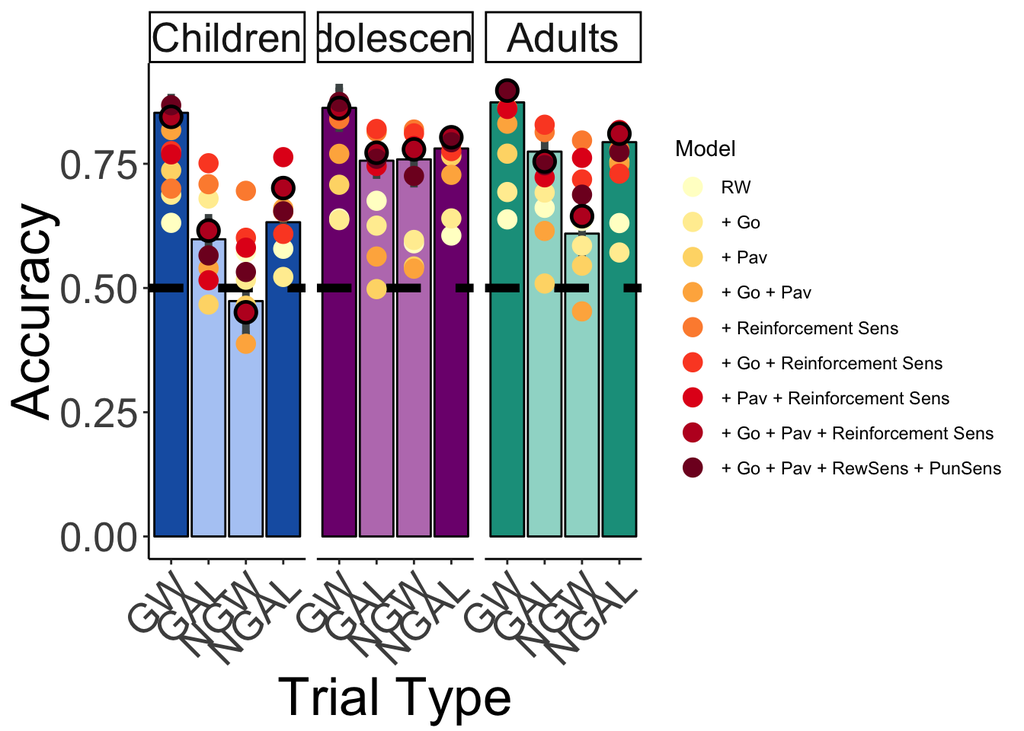